# nn

## Data Discription

The data is generated using 4 different non-linear functions, \begin{align*} g_0(x) &= a_0\sin(x), \\ g_1(x) &= a_1\sqrt{x}, \\ g_2(x) &= a_2x^3+0.3x, \\ g_3(x) &= a_3\log(1+x), \end{align*} where $a_i\sim Unif(0.1,10)$, ($i\in \{0,1,2,3 \}$). Based on these functions we have a procedure for when two time-series are dependent or not.

When the two time-series are dependent then we first create a time-series, $X$, based on two different $g$ functions. Then the other time-series, $Y$, is a $g$ function of $X$. When the time-series are independent then $Y$ is generated using the two other $g$ functions than $X$. When they are dependent they are denoted class 1 and when they are not they are denoted class 0. An example of a dependent and independent realisation is seen below.

[figure not shown]

## Neural Network Setup

In the following code we use $50,000$ realizations of $X,Y$, where len($X$)=len($Y$)=$1,000$

```python
import numpy as np
import matplotlib.pyplot as plt
from torch.utils.data import DataLoader
import torch
from sklearn.model_selection import train_test_split as tts
import torch.nn as nn
from tqdm import tqdm
import nn_module as NN
```

```python
data, labels = NN.load_data('data_(50000_1000_2)/nonlin_data.npy')
```

```python
batch_size = 100
epochs = 30
learning_rate = 0.00001
hidden_layers = [500, 500, 500]
SNR = 100
```

The input above gives the feed forward neural network:

| Input Layer | Hidden Layers | Output Layer |
| --- | --- | --- |
| len(X)*2=2,000 | -- 500 -- 500 -- 500 -- | 2 |

## Signal to noise ratio

We have tried without extra noise on the $X,Y$ realisations and got that we could classify both class 0 and 1 approximately 90% accurately. Hence, we tried adding some noise based on an SNR.

```python
P_noise = np.mean(data**2, axis=1)/np.full((data.shape[0],
                                            data.shape[2]), SNR)

noise = np.zeros(data.shape)
mu = np.zeros((data.shape[1], 1))
for i in range(len(data)):
    Xi_noise = np.random.normal(mu.copy(),
                                P_noise[i][0],
                                (data.shape[1], 1))

    Yi_noise = np.random.normal(mu.copy(),
                                P_noise[i][1],
                                (data.shape[1], 1))

    noise[i] = np.concatenate([Xi_noise, Yi_noise], axis=1)

data += noise
```

```python
# This block converts data from np to torch and adjusts
# to the desired format for the training and test.

data_trn_np, data_tst_np, label_trn_np, label_tst_np = \
    tts(data, labels, test_size=0.1)

label_train_reshaped = np.zeros((len(label_trn_np), 2))
label_test_reshaped = np.zeros((len(label_tst_np), 2))

for i, trn in enumerate(label_trn_np):
    label_train_reshaped[i, int(trn)] = 1

for i, tst in enumerate(label_tst_np):
    label_test_reshaped[i, int(tst)] = 1

data_train = NN.NumbersDataset(data_trn_np, label_train_reshaped)
data_test = NN.NumbersDataset(data_tst_np, label_test_reshaped)

loader_train = DataLoader(
    data_train,
    batch_size=batch_size,
    shuffle=True,
    pin_memory=True
)

loader_test = DataLoader(
    data_test,
    batch_size=batch_size,
    shuffle=True,
    pin_memory=True
)

input_size = int(data_trn_np.shape[1]*data_trn_np.shape[2])
```

```python
# creating device - Either GPU or CPU
device = torch.device("cuda" if torch.cuda.is_available() else "cpu")
```

```python
# Specifying FNN, loss function, and optimizer
model = NN.Network(
    hidden_layer_dims=hidden_layers,
    input_size=input_size,
    device=device
).to(device)

criterion = nn.CrossEntropyLoss().to(device)
optimizer = torch.optim.Adam(model.parameters(), lr=learning_rate)
```

```python
# Train the model
num_steps = len(loader_train)
loss_list = []
loss_avg_trn = []
loss_avg_tst = []
for epoch in tqdm(range(epochs)):
    for i, (value, label) in enumerate(loader_train):
        sample = value.reshape(batch_size, -1).to(device)
        label = label.view(label.shape[0], 2).to(device)

        # forward
        output = model(sample)
        loss = criterion(output, label)
        loss_list.append(loss.item())

        # backward
        optimizer.zero_grad()
        loss.backward()
        optimizer.step()


    with torch.no_grad():
        loss_test = []
        for value, label in loader_test:
            sample = value.reshape(batch_size, -1).to(device)
            label = label.view(label.shape[0], 2).to(device)

            output = model(sample)
            loss = criterion(output, label)

            loss_test.append(loss.item())

    loss_avg_trn.append(np.mean(np.array(loss_list)))
    loss_avg_tst.append(np.mean(np.array(loss_test)))

    loss_list = []
    loss_test = []
```

```python
with torch.no_grad():
    out_list = []
    label_list = []

    labs1d = []
    pred1d = []
    n_samples = 0
    n_diff = 0

    for value, label in loader_test:
        sample = value.reshape(batch_size, -1).to(device)
        label = label.view(label.shape[0], 2).to(device)
        label_list += label.tolist()

        output = model(sample)
        out_list += output.tolist()
        _, pred = torch.max(output, 1)
        _, labs = torch.max(label, 1)
        n_diff += torch.abs(pred-labs)

        pred1d += pred.tolist()
        labs1d += labs.tolist()

        n_samples += 1

pred1d = np.array(pred1d)
labs1d = np.array(labs1d)
```

```python
acc = np.count_nonzero(pred1d == labs1d)/len(labs1d)
acc0 = (len(pred1d[np.where(labs1d==0)])-
        np.sum(pred1d[np.where(labs1d==0)]))/len(np.where(labs1d==0)[0])

acc1 = np.sum(pred1d[np.where(labs1d==1)])/len(np.where(labs1d==1)[0])

print(f"{acc*100:.5f}% overall accuracy")
print(f"{acc0*100:.5f}% of 0 guessed correctly")
print(f"{acc1*100:.5f}% of 1 guessed correctly")
```

```
87.62000% overall accuracy
87.80198% of 0 guessed correctly
87.43434% of 1 guessed correctly
```

The best result we have gotten were without noise and is around 91% accuracy in the 3 tests. When setting the SNR=0.1 we still get around 75% accuracy, but at SNR=0.01 we get around 50% accuracy for both class 0 and 1.

## Plotting

The plot below is to ensure we are not overfitting the model.

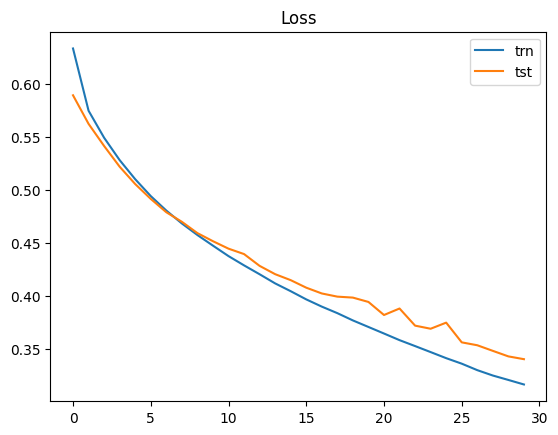

```python
plt.plot(np.array(loss_avg_trn), label="trn")
plt.plot(np.array(loss_avg_tst), label="tst")
plt.title('Loss')
plt.legend()
plt.show()
```

```python
all_X = []

for X, y in loader_test:
  all_X.append(X)

test_X = torch.cat(all_X, dim=0).numpy()

wrong_guess_idx = np.where(pred1d != labs1d)
right_guess_idx = np.where(pred1d == labs1d)
```

```python
wrong_guess = test_X[wrong_guess_idx]
right_guess = test_X[right_guess_idx]

wrong_guess_lab = labs1d[wrong_guess_idx]
right_guess_lab = labs1d[right_guess_idx]

wrong_guess_lab_pred = pred1d[wrong_guess_idx]
right_guess_lab_pred = pred1d[right_guess_idx]

corr_wrong = np.zeros(len(wrong_guess))
corr0_wrong = []
corr1_wrong = []
for i in range(len(wrong_guess)):
    corr_wrong[i] = np.corrcoef(wrong_guess[i,:,0], wrong_guess[i,:,1])[0,1]

    if wrong_guess_lab[i] == 0:
        corr0_wrong.append(corr_wrong[i])
    else:
        corr1_wrong.append(corr_wrong[i])

corr0_wrong = np.array(corr0_wrong)
corr1_wrong = np.array(corr1_wrong)

corr_right = np.zeros(len(right_guess))
corr0_right = []
corr1_right = []
for i in range(len(right_guess)):
    corr_right[i] = np.corrcoef(right_guess[i,:,0], right_guess[i,:,1])[0,1]

    if right_guess_lab[i] == 0:
        corr0_right.append(corr_right[i])
    if right_guess_lab[i] == 1:
        corr1_right.append(corr_right[i])

corr0_right = np.array(corr0_right)
corr1_right = np.array(corr1_right)
```

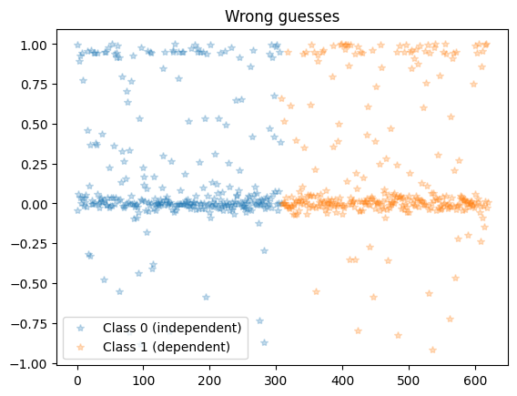

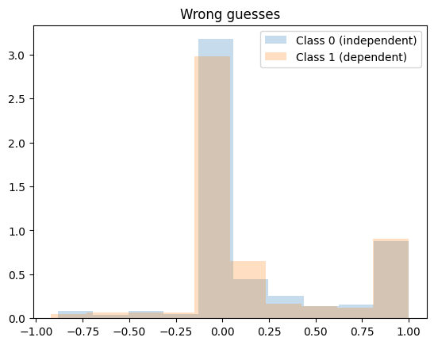

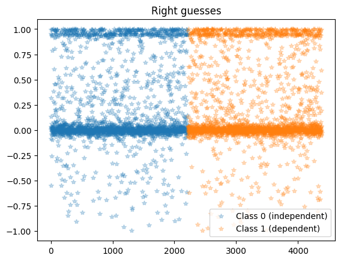

```python
x_wrong = np.linspace(0, len(corr_wrong), len(corr_wrong))
plt.plot(x_wrong[:len(corr0_wrong)], corr0_wrong, '*', alpha=0.25, label='Class 0 (independent)')
plt.plot(x_wrong[len(corr0_wrong):], corr1_wrong, '*', alpha=0.25, label='Class 1 (dependent)')
plt.title('Wrong guesses')
plt.legend()
plt.show()

plt.hist(corr0_wrong, alpha=0.25, label='Class 0 (independent)', density=True)
plt.hist(corr1_wrong, alpha=0.25, label='Class 1 (dependent)', density=True)
plt.title('Wrong guesses')
plt.legend()
plt.show()

x_right = np.linspace(0, len(corr_right), len(corr_right))
plt.plot(x_right[:len(corr0_right)], corr0_right, '*', alpha=0.25, label='Class 0 (independent)')
plt.plot(x_right[len(corr0_right):], corr1_right, '*', alpha=0.25, label='Class 1 (dependent)')
plt.title('Right guesses')
plt.legend()
plt.show()
```

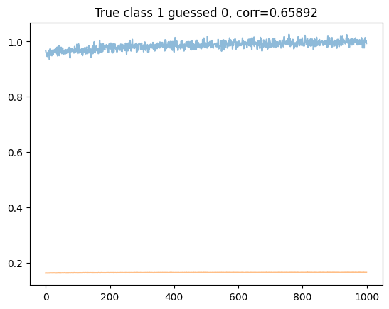

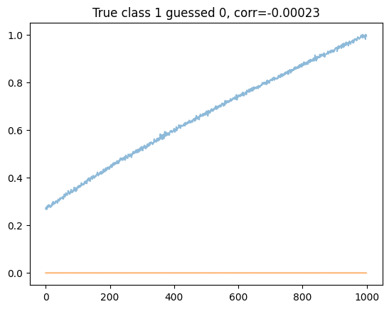

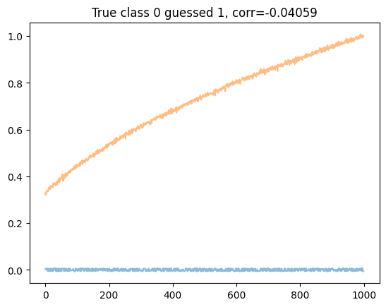

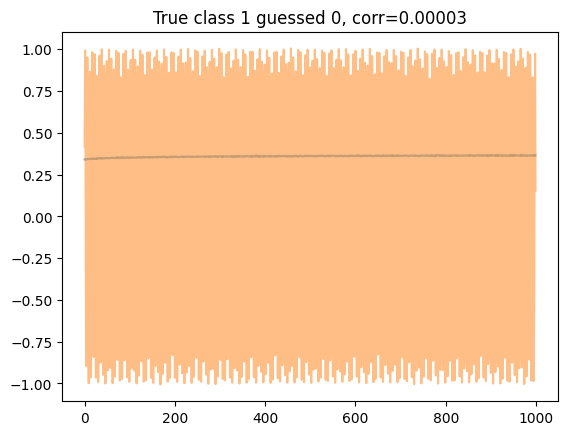

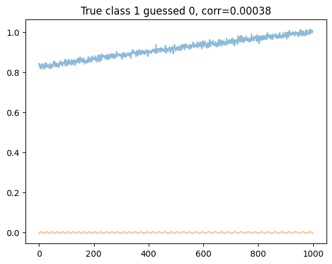

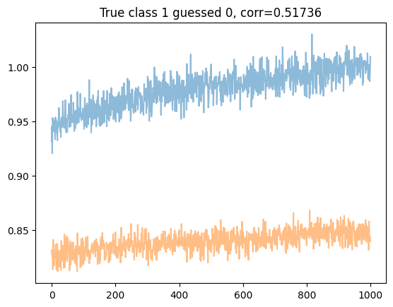

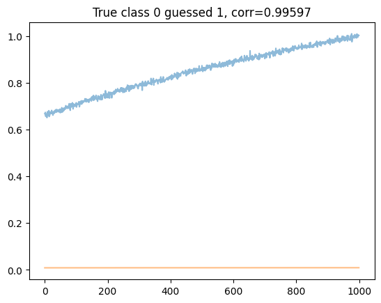

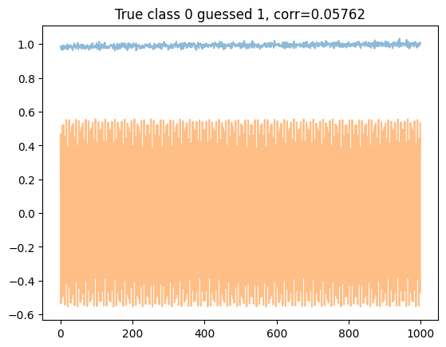

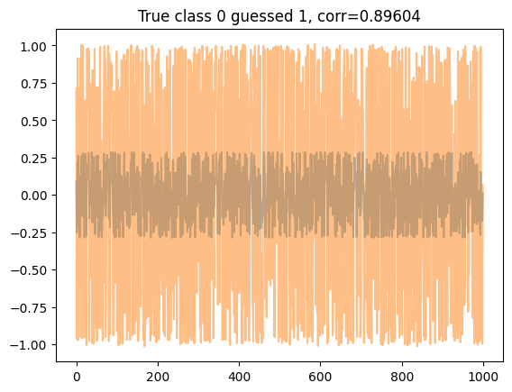

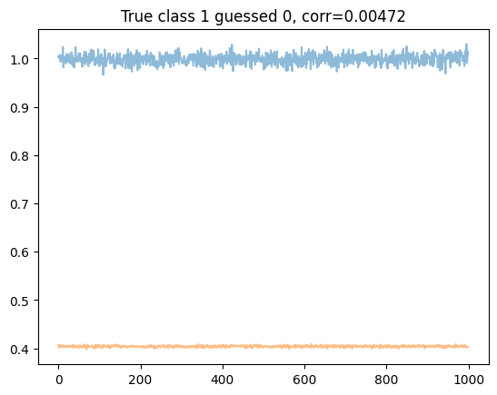

```python
for i in range(10):
    plt.plot(wrong_guess[i], alpha=0.5)
    plt.title(f'True class {wrong_guess_lab[i]} guessed {wrong_guess_lab_pred[i]}, corr={corr_wrong[i]:.5f}')
    plt.show()
```

```python
import torch.nn.functional as F

out = model(torch.concat([torch.zeros(1000), torch.ones(1000)]))
classification = torch.argmax(out).item()

if classification == 0:
    dependency = 'independent'
else:
    dependency = 'dependent'

print(f"The tested data is {dependency} \nCertainty independent = {F.softmax(out, dim=0)[0]:.5f}\nCertainty dependent   = {F.softmax(out, dim=0)[1]:.5f}")


# anders test:
coup = np.load('dat/coupled_data.npy')
ucoup = np.load('dat/uncoupled_data.npy')

coup_t = torch.from_numpy(coup).to(torch.float32)
ucoup_t = torch.from_numpy(ucoup).to(torch.float32)

out = model(ucoup_t)
classification = torch.argmax(out).item()

if classification == 0:
    dependency = 'independent'
else:
    dependency = 'dependent'

print(f"The tested data is {dependency} \nCertainty independent = {F.softmax(out, dim=0)[0]:.5f}\nCertainty dependent   = {F.softmax(out, dim=0)[1]:.5f}")
```

[output not shown]

```
The tested data is dependent
Certainty independent = 0.07814
Certainty dependent   = 0.92186
```